# Marubeni Corporation Data Challenge

Siinn Che

## Introduction

Flight delay and cancelation is one of the major problems that airlines are facing with. Our client, American Airline wants to investigate the flight delay and cancelation in order to understand potential causes of flight delays and their effects on public perception on its brand.

In this data challege, I will

- perform exploratory data analysis
- determine cause of flight delay
- investigate public perception on American Airline in regards to flight delays

The dataset is obtained from the Kaggle competition https://www.kaggle.com/usdot/flight-delays

Also, additional data is acquired from the following sources.

Twitter sentiment data: https://www.kaggle.com/crowdflower/twitter-airline-sentiment

Aircraft registration data: https://www.faa.gov/licenses_certificates/aircraft_certification/aircraft_registry/releasable_aircraft_download/

```python
df_raw.head(3)
```

|  | YEAR | MONTH | DAY | DAY_OF_WEEK | AIRLINE | FLIGHT_NUMBER | TAIL_NUMBER | ORIGIN_AIRPORT | DESTINATION_AIRPORT | SCHEDULED_DEPARTURE | ... | ARRIVAL_TIME | ARRIVAL_DELAY | DIVERTED | CANCELLED | CANCELLATION_REASON | AIR_SYSTEM_DELAY | SECURITY_DELAY | AIRLINE_DELAY | LATE_AIRCRAFT_DELAY | WEATHER_DELAY |
| --- | --- | --- | --- | --- | --- | --- | --- | --- | --- | --- | --- | --- | --- | --- | --- | --- | --- | --- | --- | --- | --- |
| 0 | 2015 | 1 | 1 | 4 | AS | 98 | N407AS | ANC | SEA | 5 | ... | 408.0 | -22.0 | 0 | 0 | NaN | NaN | NaN | NaN | NaN | NaN |
| 1 | 2015 | 1 | 1 | 4 | AA | 2336 | N3KUAA | LAX | PBI | 10 | ... | 741.0 | -9.0 | 0 | 0 | NaN | NaN | NaN | NaN | NaN | NaN |
| 2 | 2015 | 1 | 1 | 4 | US | 840 | N171US | SFO | CLT | 20 | ... | 811.0 | 5.0 | 0 | 0 | NaN | NaN | NaN | NaN | NaN | NaN |

3 rows × 31 columns

## Data Cleaning

Before we perform an exploratory analysis, I examined the data. The data is nicely structured with no obvious missing value. So in this section, I performed the following transformation.

- I converted dates given in three columns, "YEAR", "MONTH", "DATE" into a single datetime object.
- Cleaned differet data types (str, float)
- Impute missing values (delay time, reason for on-time flights)
- Retrieved full airport name
- Created boolean features representing flight delay

### Aircraft Features

At the end of the data challenge, I have learned that the most importact feature in predicting flight delays is tail number which is a unique registration assigned for each aircraft. So I obtained additional data on aircraft from, https://www.faa.gov/licenses_certificates/aircraft_certification/aircraft_registry/releasable_aircraft_download/

This dataset contains information about aircrafts such as

- Aircraft model
- Engine model
- Manufactured year
- Expiration date, etc.

```python
df_a.head(3)
```

|  | N-NUMBER | YEAR MFR | MFR MDL CODE | EXPIRATION DATE | TYPE ENGINE | TYPE AIRCRAFT |
| --- | --- | --- | --- | --- | --- | --- |
| 0 | 1 | 1988 | 3980115 | 20191130 | 5 | 5 |
| 1 | 100 | 1940 | 7100510 | 20200430 | 1 | 4 |
| 2 | 10001 | 1928 | 9601202 | 20190630 | 1 | 4 |

Now, let's clean the aircraft features so that they are suitable for building model

- Manufactured and expiration date: only year is kept
- Aircraft model and engine models are converted into categorical features

### Summary of data cleaning

Here is the dataframe after data cleaning. We only kept features of interest, and delay times are formatted in minutes. We also created boolean features for each cause of delay.

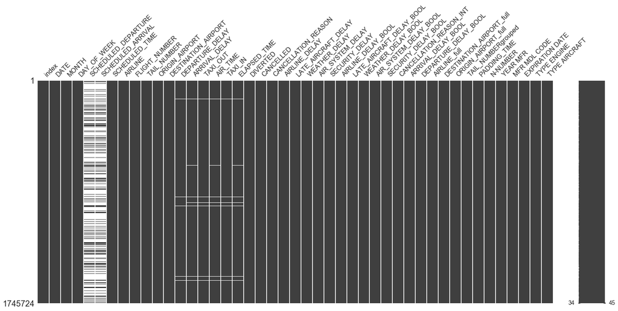

```python
# visualize missing values
msno.matrix(df)
```

## Exploratory Analysis

### Investigating each feature

As a first step, I first examined each features individually, and I will look at its distribution. This will allow us to understand the features, and it will also help us to find any outliers or wrong values.

#### Discrete feature distribution

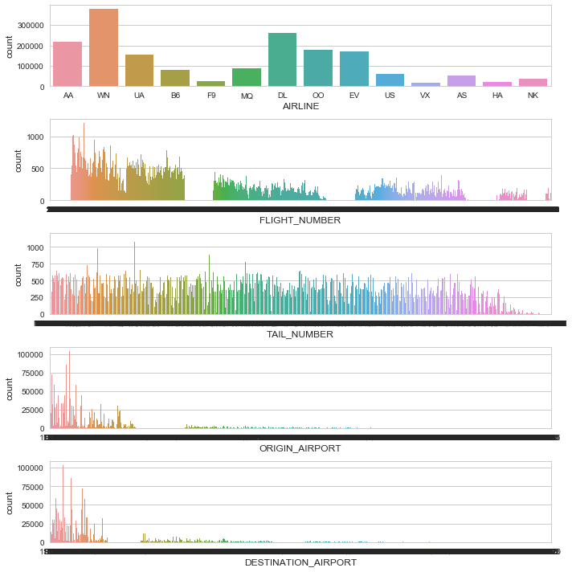

```python
# create figure and axes
fig, ax = plt.subplots(5,1, figsize=(10,10))

# loop over each feature names to create distributions
for i, feature in enumerate(features_cat):
    sns.countplot(x = feature, data=df, ax=ax[i])

# use tight layout
plt.tight_layout()
```

#### Continuous feature distribution

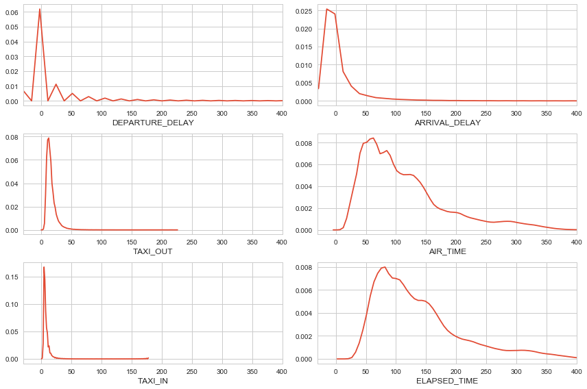

```python
# create figure and axes
fig, ax = plt.subplots(3,2, figsize=(12,8))
ax.flatten()

# loop over each feature names to create distributions
for i, feature in enumerate(features_continuous):

    # get row and column index given integer
    row = get_matrix_index(i)[0]
    column = get_matrix_index(i)[1]

    sns.distplot(df.loc[(df["CANCELLED"] == False) & (df["DIVERTED"] == False)][feature], ax=ax[row][column], hist=False)
    ax[row][column].set_xlim([-30,400])

# use tight layout
plt.tight_layout()
```

#### Average Departure and Arrival Delay

```python
df.loc[(df["CANCELLED"] == False) &
       (df["DIVERTED"] == False) &
       (df["ARRIVAL_DELAY"] > 0)][["DEPARTURE_DELAY", "ARRIVAL_DELAY"]].describe()
```

|  | DEPARTURE_DELAY | ARRIVAL_DELAY |
| --- | --- | --- |
| count | 626588.000000 | 626588.000000 |
| mean | 30.287275 | 33.116838 |
| std | 54.444369 | 52.803449 |
| min | -36.000000 | 1.000000 |
| 25% | 0.000000 | 6.000000 |
| 50% | 13.000000 | 15.000000 |
| 75% | 38.000000 | 38.000000 |
| max | 1631.000000 | 1638.000000 |

The above two describes show that:

- For the delayed flights, average arrival delay is ~33 minutes
- For the delayed flights, average departure delay is ~30 minutes

which seems reasonable based on the personal experience.

### Relation between Flight Delay and Features

#### Flight Delay for Airlines

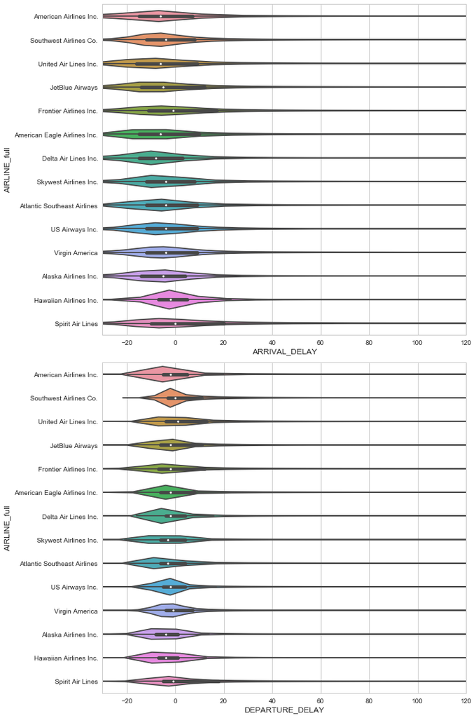

```python
# create figure and axes
fig, ax = plt.subplots(2,1, figsize=(10,15))

sns.violinplot(
        x="ARRIVAL_DELAY",
        y="AIRLINE_full",
        data=df.loc[(df["CANCELLED"] == False) &(df["DIVERTED"] == False)], ax=ax[0])
sns.violinplot(
        x="DEPARTURE_DELAY",
        y="AIRLINE_full",
        data=df.loc[(df["CANCELLED"] == False) &(df["DIVERTED"] == False)], ax=ax[1])

ax[0].set_xlim([-30,120])
ax[1].set_xlim([-30,120])
plt.tight_layout()
```

```python
df.groupby("AIRLINE_full")["DEPARTURE_DELAY"].mean().reset_index().sort_values("DEPARTURE_DELAY", ascending=False)
```

|  | AIRLINE_full | DEPARTURE_DELAY |
| --- | --- | --- |
| 10 | Spirit Air Lines | 15.895255 |
| 12 | United Air Lines Inc. | 14.528256 |
| 5 | Frontier Airlines Inc. | 13.751506 |
| 7 | JetBlue Airways | 11.508218 |
| 9 | Southwest Airlines Co. | 10.526728 |
| 2 | American Eagle Airlines Inc. | 10.193348 |
| 1 | American Airlines Inc. | 8.895231 |
| 13 | Virgin America | 8.865499 |
| 3 | Atlantic Southeast Airlines | 8.680125 |
| 8 | Skywest Airlines Inc. | 7.897144 |
| 4 | Delta Air Lines Inc. | 7.348930 |
| 11 | US Airways Inc. | 6.082069 |
| 0 | Alaska Airlines Inc. | 1.886829 |
| 6 | Hawaiian Airlines Inc. | 0.594147 |

```python
df.groupby("AIRLINE_full")["ARRIVAL_DELAY"].mean().reset_index().sort_values("ARRIVAL_DELAY", ascending=False)
```

|  | AIRLINE_full | ARRIVAL_DELAY |
| --- | --- | --- |
| 10 | Spirit Air Lines | 14.471849 |
| 5 | Frontier Airlines Inc. | 12.970194 |
| 7 | JetBlue Airways | 6.713174 |
| 3 | Atlantic Southeast Airlines | 6.575611 |
| 2 | American Eagle Airlines Inc. | 6.484849 |
| 8 | Skywest Airlines Inc. | 5.944382 |
| 12 | United Air Lines Inc. | 5.495969 |
| 13 | Virgin America | 4.512566 |
| 9 | Southwest Airlines Co. | 4.276870 |
| 11 | US Airways Inc. | 3.633171 |
| 1 | American Airlines Inc. | 3.442930 |
| 6 | Hawaiian Airlines Inc. | 2.173203 |
| 4 | Delta Air Lines Inc. | 0.128061 |
| 0 | Alaska Airlines Inc. | -0.854943 |

This is very interesting. This violin plot shows the distribution of arrival and departure delay.

Now, I investigated delay as a function of airports.

#### Flight Delay in Popular Airports

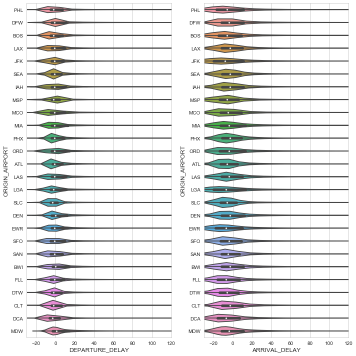

```python
# create figure and axes
fig, ax = plt.subplots(1,2, figsize=(10,10))

# create violin plots for delay vs. airport
sns.violinplot(
        x="DEPARTURE_DELAY",
        y="ORIGIN_AIRPORT",
        data=df_airport_origin, ax=ax[0])
sns.violinplot(
        x="ARRIVAL_DELAY",
        y="ORIGIN_AIRPORT",
        data=df_airport_origin, ax=ax[1])

ax[0].set_xlim([-30,120])
ax[1].set_xlim([-30,120])
plt.tight_layout()
```

#### Average Flight Delay in Popular Airports

```python
df_airport.groupby("ORIGIN_AIRPORT_full")["DEPARTURE_DELAY"].mean().reset_index().sort_values("DEPARTURE_DELAY", ascending=False).head(5)
```

|  | ORIGIN_AIRPORT_full | DEPARTURE_DELAY |
| --- | --- | --- |
| 3 | Chicago O'Hare International Airport | 14.124171 |
| 17 | Newark Liberty International Airport | 13.757076 |
| 0 | Baltimore-Washington International Airport | 13.254607 |
| 12 | LaGuardia Airport (Marine Air Terminal) | 13.058372 |
| 2 | Chicago Midway International Airport | 12.889489 |

```python
df_airport.groupby("DESTINATION_AIRPORT_full")["ARRIVAL_DELAY"].mean().reset_index().sort_values("ARRIVAL_DELAY", ascending=False).head(5)
```

|  | DESTINATION_AIRPORT_full | ARRIVAL_DELAY |
| --- | --- | --- |
| 263 | St. Cloud Regional Airport | 35.260870 |
| 250 | Sawyer International Airport | 20.075000 |
| 275 | Trenton Mercer Airport | 17.968013 |
| 13 | Aspen-Pitkin County Airport | 17.826638 |
| 169 | Mammoth Yosemite Airport | 17.756098 |

### Delay reasons

- Airline
- Late aircraft
- Weather
- National air system
- Security

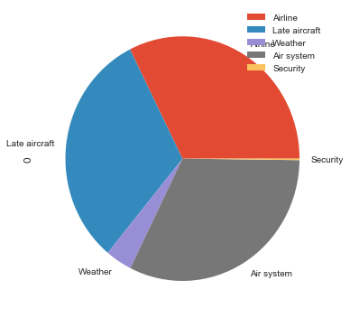

```python
# create figure and axes
fig, ax = plt.subplots(1,1, figsize=(5,5))

# create pie plot
pd.DataFrame(series_delay, index=["Airline",
                           "Late aircraft",
                           "Weather",
                           "Air system",
                           "Security"]).plot.pie(subplots=True, ax = ax)
plt.tight_layout()
```

### Aircraft tail number and delay

Before closing the exploratory analysis, I wanted to see if delay is more often caused by some aircraft specified by tail number. Here is the results. Because some aircraft only have small number of flights, I only plotted the aircrafts that have more than 10 flights.

#### Aircraft tail number and delay

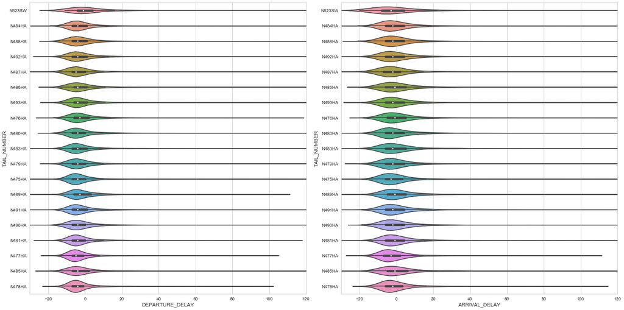

```python
# create figure and axes
fig, ax = plt.subplots(1,2, figsize=(20,10))

# create violin plots for delay vs. airport
sns.violinplot(
        x="DEPARTURE_DELAY",
        y="TAIL_NUMBER",
        data=df_freq, ax=ax[0])
sns.violinplot(
        x="ARRIVAL_DELAY",
        y="TAIL_NUMBER",
        data=df_freq, ax=ax[1])

ax[0].set_xlim([-30,120])
ax[1].set_xlim([-30,120])
plt.tight_layout()
```

### Delay as a function of taxi in, taxi out, air time

Now, I investigated the delays as a function of features. It is possible that flights are more often delayed when taxi in, taxi out times are longer. In order to investigate this, I made scatter plots, feature vs arrival and departure delay.

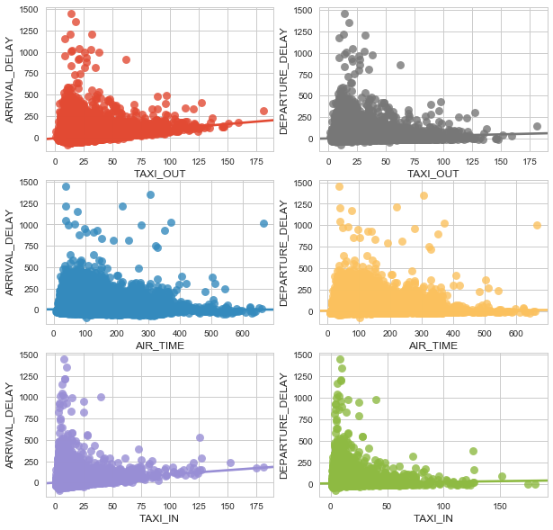

```python
# define features to plot
numeric_features = ["TAXI_OUT","AIR_TIME","TAXI_IN"]

# create figure and axes
fig, ax = plt.subplots(3,2, figsize=(10,10))

for i, feature in enumerate(numeric_features):
    sns.regplot(x=feature, y="ARRIVAL_DELAY", data=df.loc[df["PADDING_TIME"] < 1440], scatter_kws={"s": 80}, ax=ax[i][0])

for i, feature in enumerate(numeric_features):
    sns.regplot(x=feature, y="DEPARTURE_DELAY", data=df.loc[df["PADDING_TIME"] < 1440], scatter_kws={"s": 80}, ax=ax[i][1])
```

## Random Forest Classifier

### Features and Label

I can continue to investigate the relation between features and delay, but this would be very time-consuming and tedious process. Instead, I would like to build random forest classification model for each type of delay (Airline, Late air craft, etc.), and I will look at the important features. Then I can re-visit the effect of these important features.

So let's first prepare a datafarme with features.

```python
# create X
X = df_not_cancelled[[
            "MONTH",
            "DAY_OF_WEEK",
            "AIRLINE",
            "FLIGHT_NUMBER",
            "TAIL_NUMBER",
            "ORIGIN_AIRPORT",
            "DESTINATION_AIRPORT",
            "TAXI_OUT",
            "AIR_TIME",
            "TAXI_IN",
            ]]

y1 = df_not_cancelled[[
        "ARRIVAL_DELAY_BOOL"]]

y2 = df_not_cancelled[[
        "DEPARTURE_DELAY_BOOL"]]
```

### Grid Search

However, often GridSearch results in over-fitting, and the parameters are further adjusted to avoid over-fitting the training samples.

```python
# flag for grid search
GridSearch = True


if GridSearch:
    # perform GridSearch for RandomForest
    param_grid =    {
                    'n_estimators':[100], 'max_features': [3,5,7],
                    'max_depth': [3,4,5],
                    'min_samples_leaf': [2],
                    'class_weight': ['balanced']
                    }

    # initiate grid search
    grid_search_arrival = GridSearchCV( estimator=model_airline_arrival, param_grid=param_grid,
                                cv=n_cross_validation, n_jobs=-1, scoring="f1")

    grid_search_departure = GridSearchCV( estimator=model_airline_departure, param_grid=param_grid,
                                cv=n_cross_validation, n_jobs=-1, scoring="f1")

    # fit grid search
    grid_search_arrival.fit(X_train, y1_train.values.ravel())
    grid_search_departure.fit(X_train, y2_train.values.ravel())

    # best parameters found by GridSearch
    params_arrival = grid_search_arrival.best_params_
    params_departure = grid_search_departure.best_params_
    print(grid_search_arrival.best_params_)
    print(grid_search_departure.best_params_)
```

```
{'class_weight': 'balanced', 'max_depth': 5, 'max_features': 5, 'min_samples_leaf': 2, 'n_estimators': 100}
{'class_weight': 'balanced', 'max_depth': 4, 'max_features': 3, 'min_samples_leaf': 2, 'n_estimators': 100}
```

Then we set model parameters with the hyperparameters obtained from GridSearch.

### Learning Curve

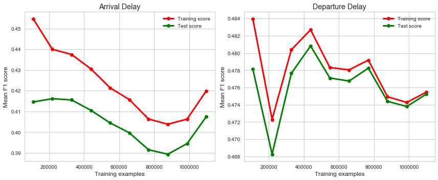

```python
# create axes
fig, (ax1, ax2) = plt.subplots(1,2, figsize=(12,5))

# plot learning curve for Arrival delay
ax1.plot(train_sizes_arrival, train_scores_arrival_mean, color="r", marker="o", linewidth=3, label="Training score")
ax1.plot(train_sizes_arrival, test_scores_arrival_mean, color="g", marker="o", linewidth=3, label="Test score")

# plot learning curve for Departure delay
ax2.plot(train_sizes_departure, train_scores_departure_mean, color="r", marker="o", linewidth=3, label="Training score")
ax2.plot(train_sizes_departure, test_scores_departure_mean, color="g", marker="o", linewidth=3, label="Test score")

# customize plots
for ax in (ax1, ax2):
    ax.legend()
    #ax.set_ylim([0.5,1])
    ax.set_ylabel("Mean F1 score")
    ax.set_xlabel("Training examples")

ax1.set_title("Arrival Delay")
ax2.set_title("Departure Delay")

# save figure
plt.tight_layout()
```

- The plots show that the training score and the test score converges nicely at larger sample size, indiciating that the models aren't overfitting.
- The fact that the training and the test score converge indicates that obtaining more sample wouldn't help us to build a better model.

### Cross-validation metrics

In addition to learning curves, the performance of estimators are evaluated using cross-validated metrics such as accuracay and F! score. The scores are calculated for two models using 5-fold cross-validation.

```python
# cross-validated accuracy
print("Arrival delay model")
print("train accuracy = %0.3f (+/- %0.3f)" % (scores_arrival["train_accuracy"].mean(), scores_arrival["train_accuracy"].std()*100))
print("test accuracy = %0.3f (+/- %0.3f)" % (scores_arrival["test_accuracy"].mean(), scores_arrival["test_accuracy"].std()*100))

print("Departure delay model")
print("train accuracy = %0.3f (+/- %0.3f)" % (scores_departure["train_accuracy"].mean(), scores_departure["train_accuracy"].std()*100))
print("test accuracy = %0.3f (+/- %0.3f)" % (scores_departure["test_accuracy"].mean(), scores_departure["test_accuracy"].std()*100))

# cross-validated f1
print("Arrival delay model")
print("train f1 = %0.3f (+/- %0.3f)" % (scores_arrival["train_f1"].mean(), scores_arrival["train_f1"].std()*100))
print("test f1 = %0.3f (+/- %0.3f)" % (scores_arrival["test_f1"].mean(), scores_arrival["test_f1"].std()*100))

print("Departure delay model")
print("train f1 = %0.3f (+/- %0.3f)" % (scores_departure["train_f1"].mean(), scores_departure["train_f1"].std()*100))
print("test f1 = %0.3f (+/- %0.3f)" % (scores_departure["test_f1"].mean(), scores_departure["test_f1"].std()*100))
```

```
Arrival delay model
train accuracy = 0.521 (+/- 0.343)
test accuracy = 0.511 (+/- 0.357)
Departure delay model
train accuracy = 0.593 (+/- 0.425)
test accuracy = 0.593 (+/- 0.432)
Arrival delay model
train f1 = 0.420 (+/- 0.478)
test f1 = 0.408 (+/- 0.488)
Departure delay model
train f1 = 0.476 (+/- 0.812)
test f1 = 0.476 (+/- 0.853)
```

### Fitting Models and Making Prediction

In the previous section, the hyperparameters for two models are chosen by learning curves and cross-validated scores. Now, the models are trained using the training dataset, and predictions are made on training and test datasets.

After making predictions, the performance is evaluated by confusion matrix.

```
Confusion matrix, without normalization
[[118798  98762]
 [ 68443  56789]]
Confusion matrix, without normalization
[[134860  80831]
 [ 60314  66787]]
```

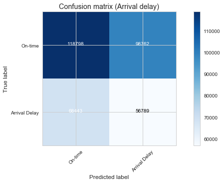

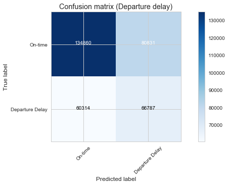

```python
# Compute confusion matrix
cnf_matrix = confusion_matrix(y1_test, y_pred_test_arrival)
np.set_printoptions(precision=2)
class_names = ["On-time", "Arrival Delay"]

# create figure and axes
fig, ax = plt.subplots(1,1, figsize=(10,5))

# Plot normalized confusion matrix
plot_confusion_matrix(cnf_matrix, classes=class_names, normalize=False,
                      title='Confusion matrix (Arrival delay)')

# Compute confusion matrix
cnf_matrix = confusion_matrix(y2_test, y_pred_test_departure)
np.set_printoptions(precision=2)
class_names = ["On-time", "Departure Delay"]

# create figure and axes
fig, ax = plt.subplots(1,1, figsize=(10,5))

# Plot normalized confusion matrix
plot_confusion_matrix(cnf_matrix, classes=class_names, normalize=False,
                      title='Confusion matrix (Departure delay)')
```

### Feature Importance

In random forest classifier, feature importance is calculated by gini imputity.

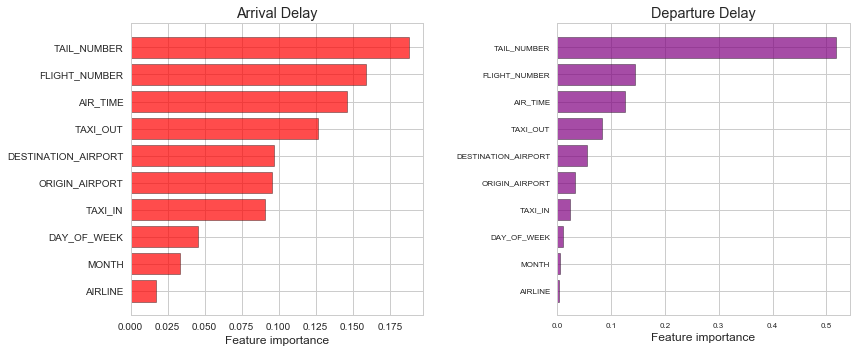

```python
# create figure and axes
fig, (ax1, ax2) = plt.subplots(1,2,figsize=(12,5))
n_features = 10

# get feature name and feature importance
feature_name = X.columns.values
feature_importance_arrival = model_airline_arrival.feature_importances_
feature_importance_departure = model_airline_departure.feature_importances_

# pick top features
top_features_arrival = sorted(   zip(feature_name, feature_importance_arrival),
                            key=lambda x:x[1], reverse=True)
top_features_departure = sorted(   zip(feature_name, feature_importance_departure),
                            key=lambda x:x[1], reverse=True)

# make horizontal bar plot
ax1.barh(np.arange(n_features), [x[1] for x in top_features_arrival], color="r", alpha=0.7, edgecolor="black")
ax2.barh(np.arange(n_features), [x[1] for x in top_features_departure], color="purple", alpha=0.7, edgecolor="black")

# customize plots
for ax in (ax1, ax2):
    ax.set_yticks(np.arange(n_features))
    ax.set_yticklabels([x[0] for x in top_features_arrival])
    ax.invert_yaxis()
    ax.set_xlabel("Feature importance")

ax1.set_title("Arrival Delay")
ax2.set_title("Departure Delay")

plt.tight_layout()
plt.tick_params(axis='both', which='major', labelsize=8)
```

## Random Forest with additional Aircraft Data

### Features and label

```python
# create X
X = df_not_cancelled[[
            "MONTH",
            "DAY_OF_WEEK",
            "AIRLINE",
            "FLIGHT_NUMBER",
            "TAIL_NUMBER",
            "ORIGIN_AIRPORT",
            "DESTINATION_AIRPORT",
            "TAXI_OUT",
            "AIR_TIME",
            "TAXI_IN",
            "YEAR MFR",
            "MFR MDL CODE",
            "EXPIRATION DATE",
            "TYPE ENGINE",
            "TYPE AIRCRAFT",
            ]]

y1 = df_not_cancelled[[
        "ARRIVAL_DELAY_BOOL"]]

y2 = df_not_cancelled[[
        "DEPARTURE_DELAY_BOOL"]]
```

### Grid Search

```python
# flag for grid search
GridSearch = True


if GridSearch:
    # perform GridSearch for RandomForest
    param_grid =    {
                    'n_estimators':[100], 'max_features': [3,4,5],
                    'max_depth': [3,4,5],
                    'min_samples_leaf': [2],
                    'class_weight': ['balanced']
                    }

    # initiate grid search
    grid_search_arrival = GridSearchCV( estimator=model_airline_arrival, param_grid=param_grid,
                                cv=n_cross_validation, n_jobs=-1, scoring="f1")

    grid_search_departure = GridSearchCV( estimator=model_airline_departure, param_grid=param_grid,
                                cv=n_cross_validation, n_jobs=-1, scoring="f1")

    # fit grid search
    grid_search_arrival.fit(X_train, y1_train.values.ravel())
    grid_search_departure.fit(X_train, y2_train.values.ravel())

    # best parameters found by GridSearch
    params_arrival = grid_search_arrival.best_params_
    params_departure = grid_search_departure.best_params_
    print(grid_search_arrival.best_params_)
    print(grid_search_departure.best_params_)
```

```
{'class_weight': 'balanced', 'max_depth': 3, 'max_features': 5, 'min_samples_leaf': 2, 'n_estimators': 100}
{'class_weight': 'balanced', 'max_depth': 5, 'max_features': 3, 'min_samples_leaf': 2, 'n_estimators': 100}
```

### Learning Curve

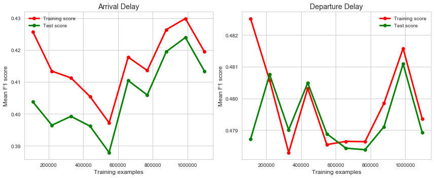

```python
# create axes
fig, (ax1, ax2) = plt.subplots(1,2, figsize=(12,5))

# plot learning curve for Arrival delay
ax1.plot(train_sizes_arrival, train_scores_arrival_mean, color="r", marker="o", linewidth=3, label="Training score")
ax1.plot(train_sizes_arrival, test_scores_arrival_mean, color="g", marker="o", linewidth=3, label="Test score")

# plot learning curve for Departure delay
ax2.plot(train_sizes_departure, train_scores_departure_mean, color="r", marker="o", linewidth=3, label="Training score")
ax2.plot(train_sizes_departure, test_scores_departure_mean, color="g", marker="o", linewidth=3, label="Test score")

# customize plots
for ax in (ax1, ax2):
    ax.legend()
    #ax.set_ylim([0.5,1])
    ax.set_ylabel("Mean F1 score")
    ax.set_xlabel("Training examples")

ax1.set_title("Arrival Delay")
ax2.set_title("Departure Delay")

# save figure
plt.tight_layout()
```

### Fitting models and making prediction using aircraft data

```
Confusion matrix, without normalization
[[119446  98249]
 [ 68494  56603]]
Confusion matrix, without normalization
[[141860  73735]
 [ 63411  63786]]
```

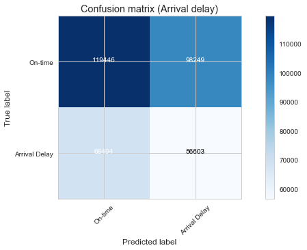

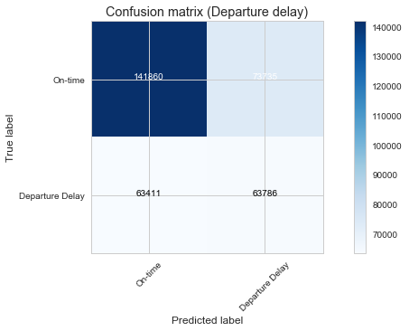

```python
# Compute confusion matrix
cnf_matrix = confusion_matrix(y1_test, y_pred_test_arrival)
np.set_printoptions(precision=2)
class_names = ["On-time", "Arrival Delay"]

# create figure and axes
fig, ax = plt.subplots(1,1, figsize=(10,5))

# Plot normalized confusion matrix
plot_confusion_matrix(cnf_matrix, classes=class_names, normalize=False,
                      title='Confusion matrix (Arrival delay)')

# Compute confusion matrix
cnf_matrix = confusion_matrix(y2_test, y_pred_test_departure)
np.set_printoptions(precision=2)
class_names = ["On-time", "Departure Delay"]

# create figure and axes
fig, ax = plt.subplots(1,1, figsize=(10,5))

# Plot normalized confusion matrix
plot_confusion_matrix(cnf_matrix, classes=class_names, normalize=False,
                      title='Confusion matrix (Departure delay)')
```

### Feature Importance

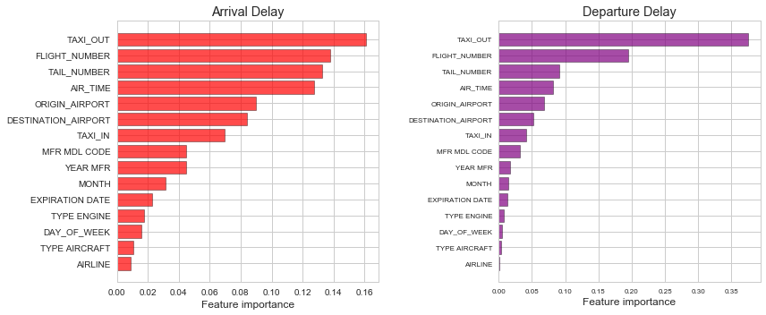

```python
#### create figure and axes
fig, (ax1, ax2) = plt.subplots(1,2,figsize=(12,5))
n_features = 15

# get feature name and feature importance
feature_name = X.columns.values
feature_importance_arrival = model_airline_arrival.feature_importances_
feature_importance_departure = model_airline_departure.feature_importances_

# pick top features
top_features_arrival = sorted(   zip(feature_name, feature_importance_arrival),
                            key=lambda x:x[1], reverse=True)
top_features_departure = sorted(   zip(feature_name, feature_importance_departure),
                            key=lambda x:x[1], reverse=True)

# make horizontal bar plot
ax1.barh(np.arange(n_features), [x[1] for x in top_features_arrival], color="r", alpha=0.7, edgecolor="black")
ax2.barh(np.arange(n_features), [x[1] for x in top_features_departure], color="purple", alpha=0.7, edgecolor="black")

# customize plots
for ax in (ax1, ax2):
    ax.set_yticks(np.arange(n_features))
    ax.set_yticklabels([x[0] for x in top_features_arrival])
    ax.invert_yaxis()
    ax.set_xlabel("Feature importance")

ax1.set_title("Arrival Delay")
ax2.set_title("Departure Delay")

plt.tight_layout()
plt.tick_params(axis='both', which='major', labelsize=8)
```

## Interpretation for American Airline

The goal of this project was to identify potential causes of flight delay for American Airline. The feature importance from random forest model suggests that flight delays are related to

- Taxi out
- Flight number
- Air time
- Origin and destination airports

This result makes sense, and it is somewhat expected as longer taxi in, taxi out time would cause flight dela, and we expact certain airpots to be more busy and have more frequent flight delays than smaller airports. However, the results also suggest that there are more non-trivial factors that play in flight delay, such as

- Tail number
- Aircraft model
- Aircraft manufactured year

### Major reasons for flight delay

- Tail number
- Aircraft model
- Aircraft manufactured year

#### Flight Delay vs Tail Number, Aircraft Model

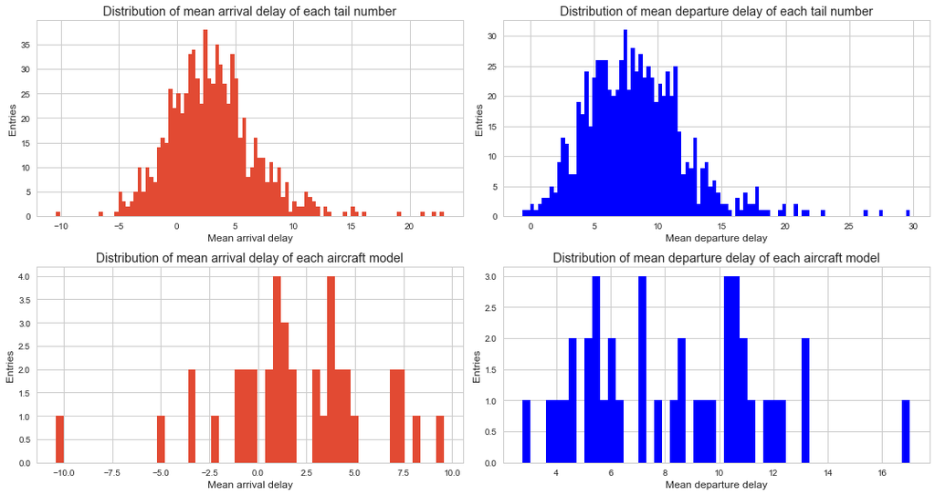

```python
# create figure and axes
fig, ax = plt.subplots(2,2, figsize=(15,8))

df_aa_freq.groupby("TAIL_NUMBER")["ARRIVAL_DELAY"].mean().hist(ax=ax[0,0], bins=100)
df_aa_freq.groupby("TAIL_NUMBER")["DEPARTURE_DELAY"].mean().hist(ax=ax[0,1], bins=100, color='b')

df_aa_freq.groupby("MFR MDL CODE")["ARRIVAL_DELAY"].mean().hist(ax=ax[1,0], bins=50)
df_aa_freq.groupby("MFR MDL CODE")["DEPARTURE_DELAY"].mean().hist(ax=ax[1,1], bins=50, color='b')

ax[0,0].set_xlabel("Mean arrival delay")
ax[0,0].set_ylabel("Entries")
ax[0,0].set_title("Distribution of mean arrival delay of each tail number")

ax[0,1].set_xlabel("Mean departure delay")
ax[0,1].set_ylabel("Entries")
ax[0,1].set_title("Distribution of mean departure delay of each tail number")

ax[1,0].set_xlabel("Mean arrival delay")
ax[1,0].set_ylabel("Entries")
ax[1,0].set_title("Distribution of mean arrival delay of each aircraft model")

ax[1,1].set_xlabel("Mean departure delay")
ax[1,1].set_ylabel("Entries")
ax[1,1].set_title("Distribution of mean departure delay of each aircraft model")


plt.tight_layout()
```

#### Flight Delay vs Aircraft Manufactured Year

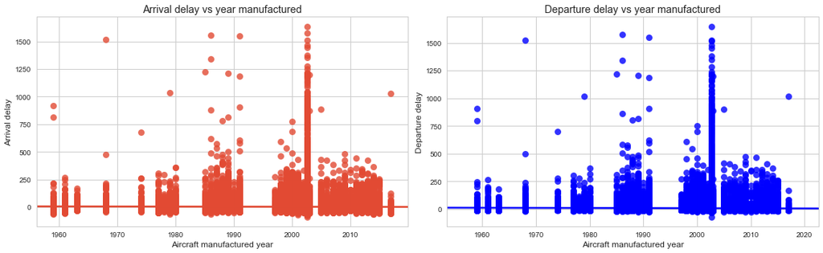

```python
# create figure and axes
fig, ax = plt.subplots(1,2, figsize=(16, 5))

sns.regplot(x="YEAR MFR", y="ARRIVAL_DELAY", data=df_aa_freq, scatter_kws={"s": 80}, ax=ax[0])
sns.regplot(x="YEAR MFR", y="DEPARTURE_DELAY", data=df_aa_freq, scatter_kws={"s": 80}, ax=ax[1], color='b')

ax[0].set_xlabel("Aircraft manufactured year")
ax[0].set_ylabel("Arrival delay")
ax[0].set_title("Arrival delay vs year manufactured")

ax[1].set_xlabel("Aircraft manufactured year")
ax[1].set_ylabel("Departure delay")
ax[1].set_title("Departure delay vs year manufactured")

plt.tight_layout()
```

### Public Perception on American Airline

In order to understand the public perception on American Airline in comparison to the competitors, the dataset containing customer's sentiment on airlines is obtained from https://www.kaggle.com/crowdflower/twitter-airline-sentiment. This dataset contains user sentiment and their reason for the sentiment is obtained from Twitter using NLP. The details can be found in the Kaggle webpage.

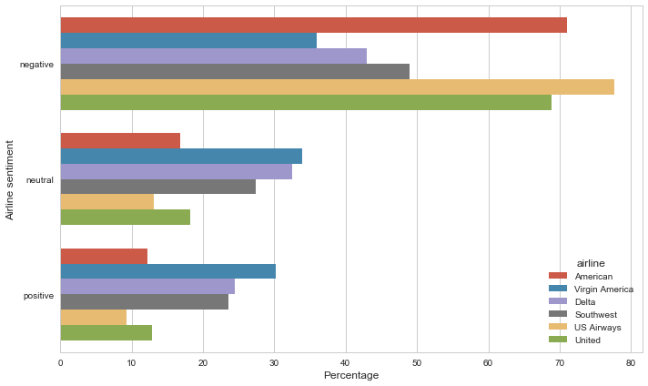

```python
# retrieve negative reason counts
airline_sentiment_counts = (df_s.groupby(['airline'])['airline_sentiment']
                     .value_counts(normalize=True)
                     .rename('percentage')
                     .mul(100)
                     .reset_index()
                     .sort_values('airline_sentiment'))

# create figure and axes
fig, ax = plt.subplots(1,1, figsize=(10,6))

# plot sentiment count
sns.barplot(y="airline_sentiment", x="percentage", hue="airline", data=airline_sentiment_counts)

ax.set_ylabel("Airline sentiment")
ax.set_xlabel("Percentage")
plt.tight_layout()
```

#### Reasons for Negative Perception

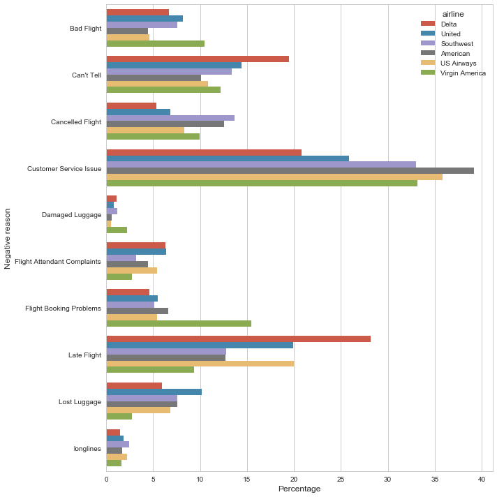

```python
# retrieve negative reason counts
negativereason_counts = (df_s.groupby(['airline'])['negativereason']
                     .value_counts(normalize=True)
                     .rename('percentage')
                     .mul(100)
                     .reset_index()
                     .sort_values('negativereason'))

# create figure and axes
fig, ax = plt.subplots(1,1, figsize=(10,10))

# plot sentiment count
#sns.barplot(y="negativereason", x="percentage", hue="airline", data=negativereason_counts)
sns.barplot(y="negativereason", x="percentage", hue="airline", data=negativereason_counts)

ax.set_ylabel("Negative reason")
ax.set_xlabel("Percentage")
plt.tight_layout()
```

## Conclusion

In this project, we examined Air Travel Consumer Report in order to identify possible causes of flight delays and understand the public perception on the client, American Airline.

- ranked 8th among 14 major airlines in departure delay
- ranked 4th among 14 major airlines in arrival delay

But the exploratory analysis also confirms that flight delays depend on many factors such as airport, taxi in, taxi out, etc. In ordert to identify and quantify important features in predicting flight delay, random forest model is built, suggesting that flight delay also depends on aircraft model and built year. There are other factors that affect flight delay such as flight number and airports, but these factors aren't something American Airline can improve as busy airports and flight numbers will always busy.

Based on this study, I suggest American Airline to: